# Autoencoders and Variational Autoencoders with Applications to Finance

## Machine Learning for Dimensionality Reduction

| Section | Theory | Implementation | Results |
| --- | --- | --- | --- |
| Principal component analysis | ☐ | ☑ | ☐ |
| Autoencoders | ☑ | ☑ | ☑ |
| Variational autoencoders | ☑ | ☑ | ☑ |
| Applications to finance: generating synthetic market data | ☑ | ☐ | ☑ |

Plenty of resources:

[figure not shown]

# Setup

This notebook can be executed with the following environment:

```
$ python -m venv venv
$ ./venv/Scripts/activate
$ pip install ipykernel nbconvert matplotlib seaborn numpy scipy scikit-learn torch
```

```python
from matplotlib.patches import Circle, Rectangle
import matplotlib.pylab as plt
import numpy as np
import seaborn as sns
sns.set_style("darkgrid")
from sklearn.decomposition import PCA
import sys
import torch
import torch.nn as nn
import torch.nn.functional as F
import torch.utils
from torch.utils.data import Dataset, DataLoader
import torch.distributions
```

```python
print('Python version:', sys.version)
print('numpy version:', np.__version__)
print('torch version:', torch.__version__)
```

```
Python version: 3.10.0 (tags/v3.10.0:b494f59, Oct  4 2021, 19:00:18) [MSC v.1929 64 bit (AMD64)]
numpy version: 1.24.3
torch version: 2.0.1+cpu
```

# Dimensionality Reduction

*Given some high-dimensional space, transform it into a low-dimensional space such that all the "important" properties are maintained and we can use the low-dimensional representation in lieu of the original, high-dimensional one.*

For example, to reduce a large number of features when preparing the inputs of a model.

In **feature selection** we remove features that we know are not important.

In **principal component analysis** (PCA) we perform a linear mapping such that the variance of the data in the low-dimensional representation is maximized. This is done by constructing the covariance matrix and computing the eigenvalues and eigenvectors. (Several variants exist.)

```python
def plot_pca(x, y):
    fig, (ax0, ax1) = plt.subplots(figsize=(8, 4), ncols=2)
    ax0.plot(x, y, 'o')

    pca = PCA(n_components=2)
    pca.fit(np.vstack((x, y)).T)

    C1, C2 = pca.components_

    ax1.plot(x, y, 'o')
    ax1.axline((0, 0), slope=C1[1] / C1[0], color='crimson', linewidth=4, alpha=0.4, label='first dim')
    ax1.axline((0, 0), slope=C2[1] / C2[0], color='green', linewidth=4, alpha=0.4, label='second dim')
    ax1.legend()
    ax1.set_title('Var Ratios: ' + ', '.join(map(lambda x: f'{x:.4f}', pca.explained_variance_ratio_)))

    for ax in (ax0, ax1):
        ax.set_xlabel('Feature #1')
        ax.set_ylabel('Feature #2')
        ax.axis('square')
    return ax0, ax1
```

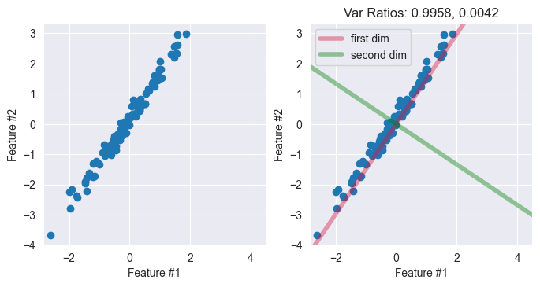

```python
np.random.seed(42)
x = np.random.randn(100)
y = 1.5 * x + 0.2 + np.random.randn(len(x)) * 0.2
plot_pca(x, y);
```

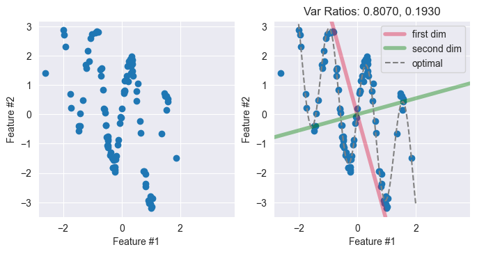

```python
y = -1.0 * x + 2 * np.sin(5 * x) + np.random.randn(len(x)) * 0.2
_, ax1 = plot_pca(x, y)
x_unif = np.linspace(-2, 2, 100)
ax1.plot(x_unif, -1.0 * x_unif + 2 * np.sin(5 * x_unif), linestyle='dashed', color='grey', label='optimal')
ax1.legend();
```

# Autoencoders

An autoencoder is a type of neural network that is trained to attempt to copy its inputs into its outputs.

Given an input $X \in \mathbb{R}^n$ and two functions $f: \mathbb{R}^n \rightarrow \mathbb{R}^m$ and $g: \mathbb{R}^m \rightarrow \mathbb{R}^n$, they compute $\hat{X} = g(f(X))$ and aim for $\hat{X} \approx X$ by making a certain loss function $\mathcal{L}(X, \hat{X})$ as small as possible.

$X \in \mathbb{R}^n \rightarrow Z \in \mathbb{R}^m \rightarrow \hat{X} \in \mathbb{R}^n$

We need $m \ll n$, as for $m \ge n$ one can simply take identity functions and perform a trivial transformation.

[figure not shown]

The function $f$ is called the *encoder* and $g$ the *decoder*, with $Z = f(X)$ the *code* in which a vector $X$ is transformed. The vectors $Z$ are often called the *latent* vectors.

The loss is the squared error loss,

$$ \mathcal{L}(X, \hat{X}) = \|X - \hat{X}\|^2. $$

### PyTorch Implementation

```python
device = 'cuda' if torch.cuda.is_available() else 'cpu'
print(f"Using device {device}.")
```

```
Using device cpu.
```

Encoder: $Z = f(X)$

```python
class Encoder(nn.Module):  # defines the function f

    # num_inputs -> dimension n
    # num_latent -> dimension m
    def __init__(self, num_inputs, num_hidden, num_latent):
        super().__init__()
        self.linear1 = nn.Linear(num_inputs, num_hidden)
        self.linear2 = nn.Linear(num_hidden, num_hidden)
        self.linear3 = nn.Linear(num_hidden, num_hidden)
        self.linear4 = nn.Linear(num_hidden, num_latent)

    def forward(self, x):  # computes Z = f(X)
        x = torch.tanh(self.linear1(x))
        x = torch.tanh(self.linear2(x))
        x = torch.tanh(self.linear3(x))
        return self.linear4(x)
```

Decoder: $\hat{X} = g(Z)$

```python
class Decoder(nn.Module):  # defines the function g

    # num_latent -> dimension m
    # num_outputs -> dimension n
    def __init__(self, num_latent, num_hidden, num_outputs):
        super().__init__()
        self.linear1 = nn.Linear(num_latent, num_hidden)
        self.linear2 = nn.Linear(num_hidden, num_hidden)
        self.linear3 = nn.Linear(num_hidden, num_hidden)
        self.linear4 = nn.Linear(num_hidden, num_outputs)

    def forward(self, z):  # computes X = g(Z)
        z = torch.tanh(self.linear1(z))
        z = torch.tanh(self.linear2(z))
        z = torch.tanh(self.linear3(z))
        return torch.relu(self.linear4(z))
```

The autoencoder simply composes the encoder and the decoder.

```python
class Autoencoder(nn.Module):  # defines g ∘ f

    def __init__(self, num_inputs, num_latent, num_hidden):
        super().__init__()
        self.encoder = Encoder(num_inputs, num_hidden, num_latent)
        self.decoder = Decoder(num_latent, num_hidden, num_inputs)

    def forward(self, x):  # computes X_hat = g(f(X))
        z = self.encoder(x)
        x_hat = self.decoder(z)
        return x_hat
```

### Preparing the Dataset

We will work with the probability density function of the normal distribution,

$$ \varphi(x; μ, σ) = \frac{1}{\sigma \sqrt{2 \pi}} \exp \left(-\frac{1}{2}\left( \frac{x - \mu}{\sigma} \right)^2 \right). $$

This function has two parameters, $\mu$ and $\sigma$, apart from the input variable $x$. What we do is to create a grid of $p$ points $[x_1, x_2, \ldots, x_p] \in [-5, 5]$ on which we will sample $\varphi(x; μ, σ)$ for given values of $\mu$ and $\sigma$; we assume $-3 \le \mu \le 3$ and $1/2 \le \sigma \le 3$.

```python
uniform_dist_μ = torch.distributions.uniform.Uniform(-3.0, 3.0)
uniform_dist_σ = torch.distributions.uniform.Uniform(0.5, 3.0)

num_entries = 100_000
num_inputs = 1_000

grid = torch.linspace(-5.0, 5.0, num_inputs)

def target_func(x, μ, σ):
    return 1 / np.sqrt(2 * np.pi) / σ * np.exp(-0.5 * (x - μ)**2 /  σ**2)
```

```python
torch.manual_seed(0)
X, Y = [], []
for _ in range(num_entries):
    μ = uniform_dist_μ.sample()
    σ = uniform_dist_σ.sample()
    X.append(target_func(grid, μ, σ))
    Y.append([μ, σ])
X = torch.vstack(X)

assert X.shape[0] == num_entries
assert X.shape[1] == num_inputs
assert X.isnan().sum() == 0.0
```

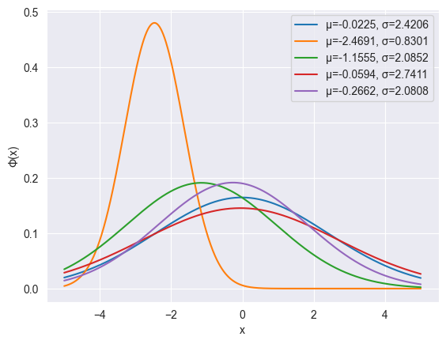

```python
for x, (μ, σ) in zip(X[:5], Y[:5]):
    plt.plot(grid, x, label=f'μ={μ.item():.4f}, σ={σ.item():.4f}')
plt.legend()
plt.xlabel('x')
plt.ylabel('Φ(x)');
```

A small wrapper to the `Dataset` class is used such that we can define a `DataLoader` and specify the batch size (here, 256) and shuffling.

```python
class FuncDataset(Dataset):

    def __init__(self, X):
        self.X = X

    def __len__(self):
        return len(self.X)

    def __getitem__(self, idx):
        return self.X[idx]
```

```python
data_loader = DataLoader(FuncDataset(X), batch_size=256, shuffle=True)
```

### Training

The training goes through the specified epochs; for each epoch we iterate over the batches, compute $\hat{X}$ given $X$ and evaluate the loss function, whose gradients are used by the optimizer to converge.

```python
def train(autoencoder, data_loader, epochs, lr, gamma, print_every):
    optimizer = torch.optim.Adam(autoencoder.parameters(), lr=lr)
    scheduler = torch.optim.lr_scheduler.ExponentialLR(optimizer, gamma=gamma)
    history = []
    for epoch in range(1, epochs + 1):
        last_lr = scheduler.get_last_lr()
        total_loss = 0.0
        for x in data_loader:
            x = x.to(device)  # to GPU if necessary
            optimizer.zero_grad()
            x_hat = autoencoder(x)
            loss = F.mse_loss(x, x_hat)
            loss.backward()
            optimizer.step()
            total_loss += loss.item()
        scheduler.step()
        if epoch % print_every == 0:
            print(f"Epoch: {epoch:3d}, lr: {last_lr[0]:.4e}, avg loss: {total_loss:.4f}")
        history.append(total_loss)
    return history
```

```python
def init_weights(m):
    if isinstance(m, nn.Linear):
        torch.nn.init.xavier_uniform_(m.weight)
        m.bias.data.fill_(0.01)
```

```python
torch.manual_seed(0)
num_latent = 2
autoencoder = Autoencoder(num_inputs=num_inputs, num_latent=num_latent, num_hidden=16).to(device)
autoencoder.apply(init_weights)
history = train(autoencoder, data_loader, epochs=100, lr=1e-3, gamma=0.98, print_every=10)
```

```
Epoch:  10, lr: 8.3375e-04, avg loss: 0.0119
Epoch:  20, lr: 6.8123e-04, avg loss: 0.0063
Epoch:  30, lr: 5.5662e-04, avg loss: 0.0046
Epoch:  40, lr: 4.5480e-04, avg loss: 0.0037
Epoch:  50, lr: 3.7160e-04, avg loss: 0.0033
Epoch:  60, lr: 3.0363e-04, avg loss: 0.0029
Epoch:  70, lr: 2.4808e-04, avg loss: 0.0027
Epoch:  80, lr: 2.0270e-04, avg loss: 0.0025
Epoch:  90, lr: 1.6562e-04, avg loss: 0.0024
Epoch: 100, lr: 1.3533e-04, avg loss: 0.0023
```

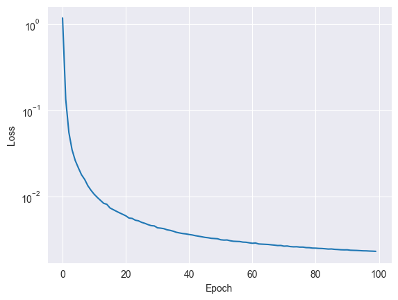

```python
plt.semilogy(history)
plt.xlabel('Epoch')
plt.ylabel('Loss');
```

### Visualizing the Results

We apply the encoder to all out dataset and store the results in the `Z` array; we then plot the distribution of $Z_1$ and $Z_2$, as well as all the points $(Z_1, Z_2)$.

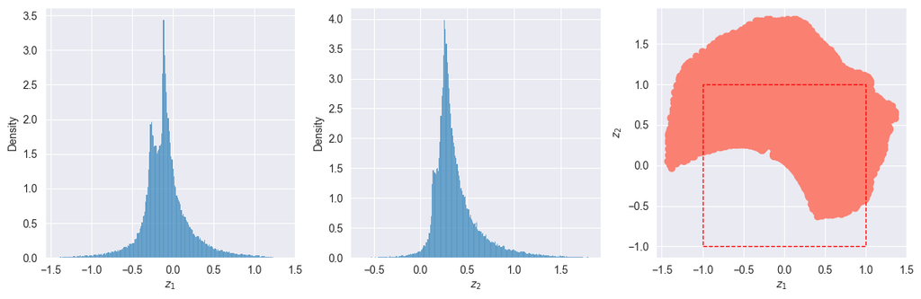

```python
Z = []
for entry in X:
    Z.append(autoencoder.encoder(entry.to(device)).cpu().detach().numpy())
Z = np.array(Z)

fig, (ax0, ax1, ax2) = plt.subplots(figsize=(12, 4), ncols=3)
sns.histplot(Z[:, 0], ax=ax0, stat='density')
sns.histplot(Z[:, 1], ax=ax1, stat='density')
ax2.scatter(Z[:, 0], Z[:, 1], color='salmon')
ax0.set_xlabel('$z_1$')
ax1.set_xlabel('$z_2$')
ax2.set_xlabel('$z_1$'); ax2.set_ylabel('$z_2$')
ax2.add_patch(Rectangle((-1, -1), 2, 2, linestyle='dashed', color='red', alpha=1, fill=None))
fig.tight_layout()
```

Sampling from the latent space, $Z \in [-1, 1] \times [-1, 1]$:

[figure not shown]

Works ok in this case, however:

- we cannot enforce any structure on the latent space, we have no control on what it will be;
- more importantly, autoencoders cannot be used for generation because there is not probabiility space to sample from.

# Variational Autoencoders

Variational autoencoders were introduced by [Kingma and Welling](https://arxiv.org/abs/1312.6114) in 2013.

Goal: *enforce a structure on the latent space Z* such that we can sample from it and generate values.

Code-wise quite similar to autoencoders, but the math is much more complicated!

We assume that the each observation variables $x$ is a sample from an unknown underlying process, whose true distribution $p^\star(x)$ is unknown. We attempt to approximate this process with a chosen model with parameters $\theta$,

$$ x \sim p_\theta(x), $$

with the goal of finding $\theta$ such that

$$ p_\theta(x) \approx p^\star(x). $$

We extend out model to include latent variables -- that is, variables that are part of our model but we don't observe, and therefore are not explicitly present in our dataset. These variables are denoted as $z$, with $p(x, z)$ the joint distribution over the observation variables $x$ and the latent variables $z$. The marginal distribution over the observation variables $p_\theta(x)$ is

$$ p_\theta(x) = \int p_\theta(x, z) dz. $$

We will write

$$ p_\theta(x, z) = p_\theta(x \vert z) p_\theta(z), $$

where both $p_\theta(x\vert z)$ and $p_\theta(z)$ will be specified by us. Once $p_\theta(z)$ and $p_\theta(x\vert z)$ are defined, we would use maximum likelyhood to define the model parameters $\theta$.

We need to introduce a distribution $q_\phi(z\vert x)$, depending on some parameters $\phi$ to be optimized as well, undefined at this point.

We have:

$$ \begin{aligned} \log p_\theta(x) & = \log \int p_\theta(x | z) p_\theta(z) dz \\ % & = \log \int p_\theta(x | z) \frac{q_\phi(z | x)}{q_\phi(z | x)} p_\theta(z) dz \\ % & \ge \int \log \left[ \frac{p_\theta(z)}{q_\phi(z | x)} p_\theta(x | z) \right] q_\phi(z | x) dz \\ % & = \underbrace{\mathbb{E}_{q_\phi(z | x)} \left[ \log{\frac{p_\theta(z)}{q_\phi(z | x)} } \right]}_{(A)} + \underbrace{\mathbb{E}_{q_\phi(z | x)}\left[ \log p_\theta(x | z) \right]}_{(B)}, \end{aligned} $$

where the inequality is a consequence of Jensen's inequality.

Let's look at the (B) first. We assume a Gaussian observation model, that is

$$ p_\theta(x | z) \sim \mathcal{N}(x; D_\theta(z), \eta I), $$

The function $D_\theta(z)$ is called the *decoder*, as it converts the latent space into the observation space. We have

$$ \begin{aligned} \log p_\theta(x | z) & = \log \mathcal{N}(x; D_\theta(\zeta), \eta I) \\ % & = -\frac{1}{2 \eta} \|x - D_\theta(z) \|^2 + const, \end{aligned} $$

to be evaluated on $q_\phi(z\vert x)$ using a Monte Carlo approximation.

Term (A) is

$$ \begin{aligned} \mathbb{E}_{q_\phi(z | x)} \left[ \log \frac{p_\theta(z)}{ q_\phi(z | x)} \right] & = \int \left[ \log p_\theta(z) - \log q_\phi(z | x) \right] dq_\phi(z | x) \\ % & = - D_{KL}(q_\phi(z | x) || p_\theta(z)). \end{aligned} $$

The [Kullback-Leibler divergence](https://en.wikipedia.org/wiki/Kullback%E2%80%93Leibler_divergence) term $D_{KL}$ will encourage $q_\phi(z \vert x)$ to be as close as possible to $p_\theta(z)$, which we model as

$$ p_\theta(z) \sim \mathcal{N}(0, I). $$

we still need to define a model for $q_\phi(z \vert x)$. Sticking to our Gaussian mixtures, we take

$$ q_\phi(z | x) \sim \mathcal{N}(z; \mu_\phi(x), \sigma_\phi(x)), $$

where $\mu_\phi(x)$ and $\sigma_\phi(x)$ are the mean and the variance of the distribution, and the output of a neural network with parameters $\phi$ and acting on $E_\phi(x)$, where $E_\phi(x)$ is another neural network, called the $encoder$, that acts on the observations.

Because of this choice, the KL divergence can be computed explicitly,

$$ \begin{aligned} D_{KL} & = \int \log \frac{q_\phi(z | x)}{p_\theta(z)} q_\phi(z | x) dz \\ & = \sum_i \frac{1}{2} \left( \sigma_{\phi, i}^2 + \mu_{\phi, i}^2 - 1 - \log \sigma_{\phi, i}(x)^2 \right). \end{aligned} $$

To apply $p_\theta(x \vert z)$ and $q_\phi(z \vert x)$, we need to draw random number from the corresponding probability distributions. Since we have selected Gaussian variates we can use the *reparametrization trick*. For example to apply $q_\phi(z \vert x)$ we would have

$$ z_i = \mu_i + \epsilon_i \sigma_i, $$

where $\epsilon_i \sim \mathcal{N}(0, 1)$, while $\mu_i$ and $\sigma_i$ are the output of the neural network.

The implementation is quite close to that of an autoencoder; the differences are in the final part of the encoder, with application of the $\mu_\phi$ and $\sigma_\phi$ to the output of $E_\phi(x)$, and the loss function, which contains the two terms we have been above.

The architecture is reported in the picture below. Note that the dense layer is connected to two separate blocks, one of which generates $\mu$ and the other $\sigma$. The part is the *encoder*. Once $Z$ has been generated, we enter the *decoder* that rebuilds the inputs from the encodings.

[figure not shown]

```python
normal_dist = torch.distributions.Normal(0, 1)
if device == 'cuda':
    normal_dist.loc = normal_dist.loc.cuda()  # hack to get sampling on the GPU
    normal_dist.scale = normal_dist.scale.cuda()
```

The encoder is a bit different from the corresponding one for non-variational autoencoders, but not by much.

```python
class VariationalEncoder(nn.Module):

    def __init__(self, num_inputs, num_hidden, num_latent):
        super().__init__()
        self.linear1 = nn.Linear(num_inputs, num_hidden)
        self.linear2 = nn.Linear(num_hidden, num_hidden)
        self.linear3 = nn.Linear(num_hidden, num_hidden)
        self.linear_mu = nn.Linear(num_hidden, num_latent)
        self.linear_logsigma2 = nn.Linear(num_hidden, num_latent)

    def forward(self, x):
        x = torch.tanh(self.linear1(x))
        x = torch.tanh(self.linear2(x))
        x = torch.tanh(self.linear3(x))
        mu =  self.linear_mu(x)
        logsigma2 = self.linear_logsigma2(x)
        sigma = torch.exp(logsigma2 / 2)
        z = mu + sigma * normal_dist.sample(mu.shape)
        integrand = (sigma**2 + mu**2 - logsigma2 - torch.ones_like(sigma)) / 2
        kl = torch.mean(torch.sum(integrand, axis=1), axis=0)
        return z, kl
```

```python
class Decoder(nn.Module):

    def __init__(self, num_latent, num_hidden, num_inputs):
        super(Decoder, self).__init__()
        self.linear1 = nn.Linear(num_latent, num_hidden)
        self.linear2 = nn.Linear(num_hidden, num_hidden)
        self.linear3 = nn.Linear(num_hidden, num_hidden)
        self.linear4 = nn.Linear(num_hidden, num_inputs)

    def forward(self, z):
        z = torch.tanh(self.linear1(z))
        z = torch.tanh(self.linear2(z))
        z = torch.tanh(self.linear3(z))
        return self.linear4(z)
```

The variational autoencoder is simply the composition of the encoder and the decoder, exactly as it was for the non-variational case.

```python
class VariationalAutoencoder(nn.Module):

    def __init__(self, num_inputs, num_hidden, num_latent):
        super().__init__()
        self.encoder = VariationalEncoder(num_inputs, num_hidden, num_latent)
        self.decoder = Decoder(num_latent, num_hidden, num_inputs)

    def forward(self, x):
        z, kl = self.encoder(x)
        x_hat = self.decoder(z)
        return x_hat, kl

    def compute_log_likelihood(self, X, X_hat, η):
        ξ = normal_dist.sample(X_hat.shape)
        X_sampled = X_hat + η.sqrt() * ξ
        return 0.5 * F.mse_loss(X, X_sampled) / η #+ η.log()
```

### Preparing the Dataset

To test the method, we build a dataset that is composed by the sampling on a uniform grid of the probability density function of the [beta distribution](https://en.wikipedia.org/wiki/Beta_distribution), for some values of the parameters $\alpha$ and $\beta$. In particular, we look at $\alpha \in [0, 5], \beta \in [0, 5]$. Ideally, the final variational autoencoder will be capable of generating distributions that look reasonable in that class.

```python
uniform_dist = torch.distributions.uniform.Uniform(0, 5)
grid = torch.linspace(0.01, 0.99, num_inputs)
```

```python
def target_func(grid, α, β):
    # return the log of the probability, not the probability itself
    return torch.distributions.Beta(α, β).log_prob(grid)
```

The generation of the dataset is in a simple loop. For simplicity we don't define a training and a test dataset.

```python
torch.manual_seed(0)
X, Y = [], []
for _ in range(num_entries):
    α = uniform_dist.sample()
    β = uniform_dist.sample()
    X.append(target_func(grid, α, β))
    Y.append([α, β])
X = torch.vstack(X)

assert X.shape[0] == num_entries
assert X.shape[1] == num_inputs
assert X.isnan().sum() == 0.0
```

We plot the first 5 entries of the dataset, seeing -- as expected -- that the shapes can be quite different.

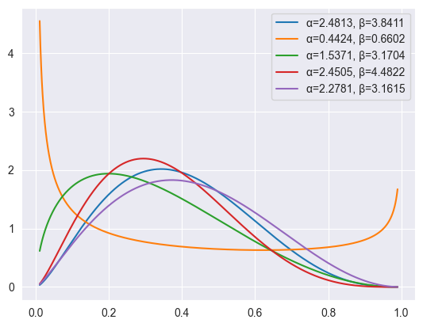

```python
for x, (α, β) in zip(X[:5], Y[:5]):
    plt.plot(grid, x.exp(), label=f'α={α.item():.4f}, β={β.item():.4f}')
plt.legend()
```

To use the `DataLoader` we define a simple customization of the `Dataset` class.

```python
class FuncDataset(Dataset):

    def __init__(self, X):
        self.X = X

    def __len__(self):
        return len(self.X)

    def __getitem__(self, idx):
        return self.X[idx]
```

### Training

```python
def init_weights(m):
    if isinstance(m, nn.Linear):
        torch.nn.init.xavier_uniform_(m.weight)
        m.bias.data.fill_(0.01)
```

```python
def train(vae, data, epochs, lr, gamma, η, β, print_every):
    η = torch.tensor(η)
    optimizer = torch.optim.Adam(vae.parameters(), lr=lr)
    scheduler = torch.optim.lr_scheduler.ExponentialLR(optimizer, gamma=gamma)
    history = []
    for epoch in range(epochs):
        last_lr = scheduler.get_last_lr()
        total_log_loss, total_kl_loss, total_loss = 0.0, 0.0, 0.0
        for x in data:
            x = x.to(device)  # GPU
            optimizer.zero_grad()
            x_hat, kl_loss = vae(x)
            log_loss = vae.compute_log_likelihood(x, x_hat, η)
            loss = log_loss + β * kl_loss
            total_log_loss += log_loss.item()
            total_kl_loss += kl_loss.item()
            total_loss += loss.item()
            loss.backward()
            optimizer.step()
        scheduler.step()
        if (epoch + 1) % print_every == 0:
            print(f"Epoch: {epoch + 1:3d}, lr: {last_lr[0]:.4e}, " \
                  f"total log loss: {total_log_loss:.4f}, total KL loss: {total_kl_loss:.4f}, " \
                  f"total loss: {total_loss:.4e}")
        history.append((total_log_loss, total_kl_loss))
    return np.array(history)
```

```python
torch.manual_seed(0)
data_loader = DataLoader(FuncDataset(X), batch_size=256, shuffle=True)
latent_dims = 2
vae = VariationalAutoencoder(num_inputs, num_hidden=32, num_latent=num_latent).to(device)
vae.apply(init_weights)
history = train(vae, data_loader, epochs=100, lr=1e-3, gamma=0.99, η=0.1**2, β=1, print_every=10)
```

```
Epoch:  10, lr: 9.1352e-04, total log loss: 2273.6985, total KL loss: 2104.7887, total loss: 4.3785e+03
Epoch:  20, lr: 8.2617e-04, total log loss: 1564.8794, total KL loss: 2022.3761, total loss: 3.5873e+03
Epoch:  30, lr: 7.4717e-04, total log loss: 1137.9883, total KL loss: 2007.6907, total loss: 3.1457e+03
Epoch:  40, lr: 6.7573e-04, total log loss: 1180.5956, total KL loss: 1996.4231, total loss: 3.1770e+03
Epoch:  50, lr: 6.1112e-04, total log loss: 1041.0120, total KL loss: 1984.6033, total loss: 3.0256e+03
Epoch:  60, lr: 5.5268e-04, total log loss: 952.2944, total KL loss: 1981.3150, total loss: 2.9336e+03
Epoch:  70, lr: 4.9984e-04, total log loss: 914.5956, total KL loss: 1980.4143, total loss: 2.8950e+03
Epoch:  80, lr: 4.5204e-04, total log loss: 842.0395, total KL loss: 1978.1929, total loss: 2.8202e+03
Epoch:  90, lr: 4.0882e-04, total log loss: 858.5363, total KL loss: 1979.2269, total loss: 2.8378e+03
Epoch: 100, lr: 3.6973e-04, total log loss: 823.4336, total KL loss: 1977.1397, total loss: 2.8006e+03
```

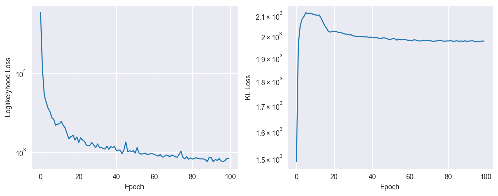

```python
fig, (ax0, ax1) = plt.subplots(figsize=(10, 4), ncols=2)
ax0.semilogy(history[:, 0])
ax0.set_xlabel('Epoch')
ax0.set_ylabel('Loglikelyhood Loss')
ax1.semilogy(history[:, 1])
ax1.set_xlabel('Epoch')
ax1.set_ylabel('KL Loss')
fig.tight_layout()
```

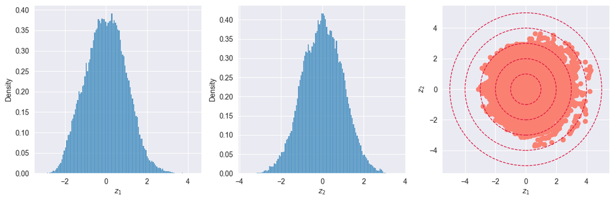

```python
Z = []
for entry in X:
    Z.append(vae.encoder(entry.unsqueeze(0).to(device))[0].cpu().detach().numpy().squeeze(0))
Z = np.array(Z)

fig, (ax0, ax1, ax2) = plt.subplots(figsize=(12, 4), ncols=3)
sns.histplot(Z[:, 0], ax=ax0, stat='density')
sns.histplot(Z[:, 1], ax=ax1, stat='density')
ax2.scatter(Z[:, 0], Z[:, 1], color='salmon')
ax0.set_xlabel('$z_1$')
ax1.set_xlabel('$z_2$')
ax2.set_xlabel('$z_1$'); ax2.set_ylabel('$z_2$')
for r in [1, 2, 3, 4, 5]:
    ax2.add_patch(Circle((0, 0), r, linestyle='dashed', color='crimson', alpha=1, fill=None))
fig.tight_layout()
```

Sampling from the latent space, $Z \in [-3, 3] \times [-3, 3]$:

[figure not shown]

# Application to Finance: Market Data Generator

[figure not shown]

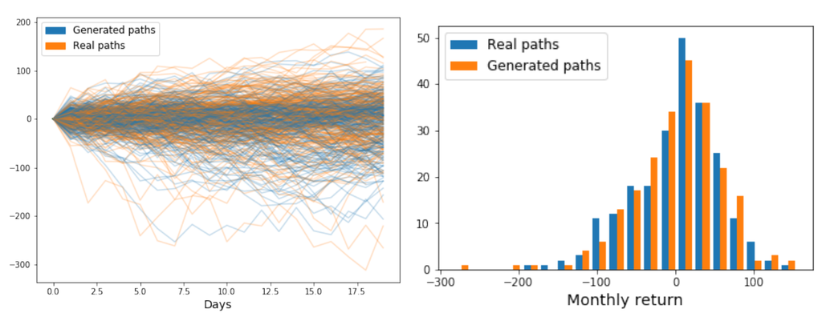

# Application to Finance: Implied Volatility Surfaces

[figure not shown]

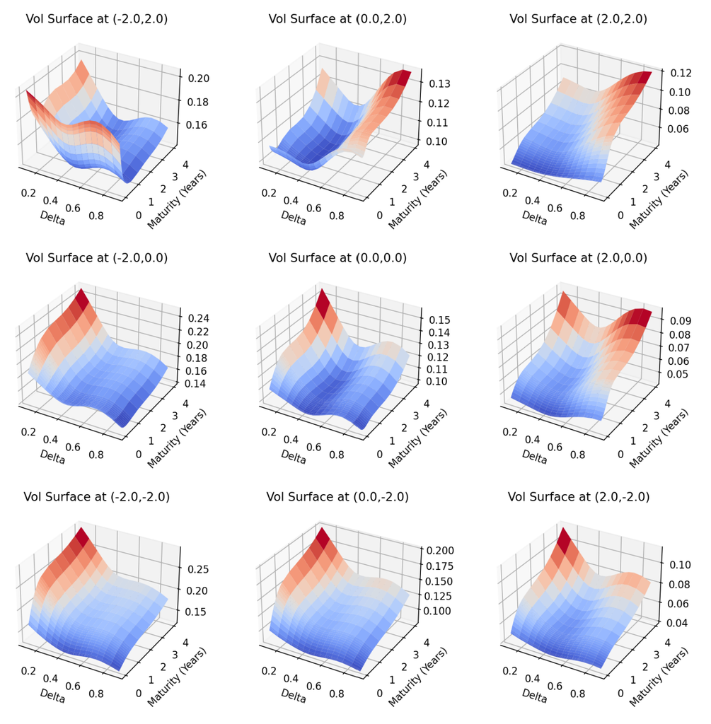

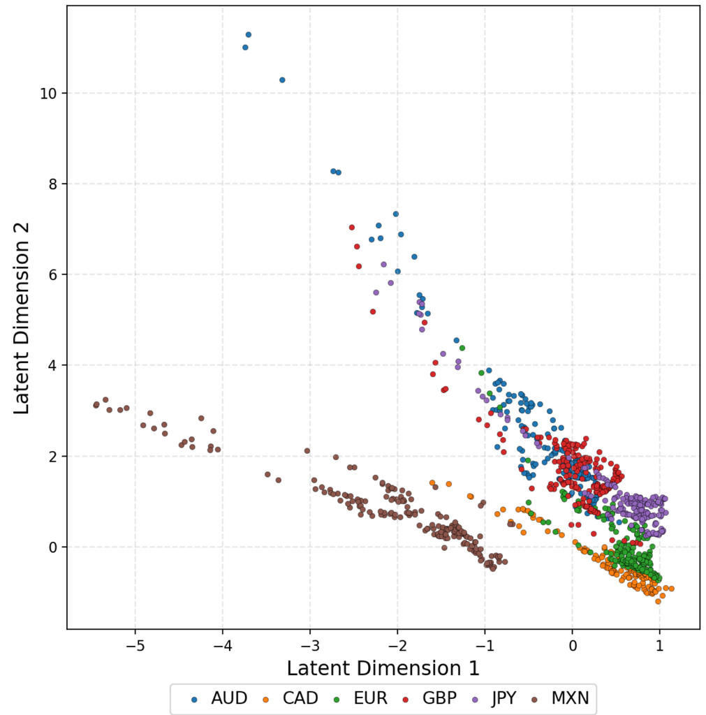